# Player UI

In this lesson, we go over the player ship systems UI. This is a sneak-peek of the in-game look:

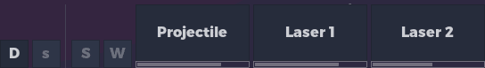

The picture shows system buttons for doors, sensors, the shield, and weapons. In this demo, we only code the doors button as it has gameplay consequences.

To implement player interaction with the rest of the systems, we need a power-management system which can be on its own an entire course.

So we are focussing on a minimum example that you can expand on your own.

## Systems

We are working with buttons representing different systems, so let’s start by adding our theme resource to the UI control node in the *TacticalSpaceCombat* scene.

Assign `res://TacticalSpaceCombat/Assets/Theme.tres` to the

[figure not shown]

`Theme` property in the *Inspector*.

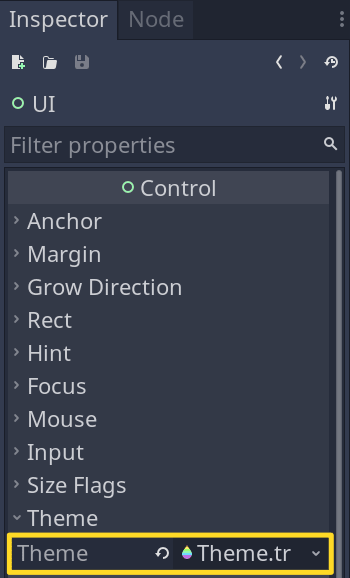

This will propagate the assigned theme to all children control nodes.

### The system button

Create a new scene and pick the

[figure not shown]

`Button` node as root. Rename it to *System* and save the file as `res://TacticalSpaceCombat/UI/UISystem.tscn`.

We use this node for all sorts of systems in the game, like doors and shields, etc.

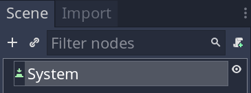

Set the default text to `S` as a placeholder. We use single letters to distinguish systems while keeping it short. This text gets replaced in code.

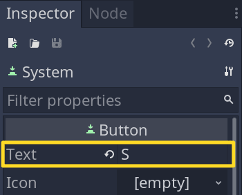

Set the *Rect -> Min Size* to `Vector2(32, 32)` for a consistent look and reset the *Size* value if needed.

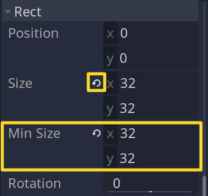

Finally, change the *Size Flags -> Vertical* settings to `Expand` and `Shrink End`. This places the

[figure not shown]

`Button` at the bottom of the parent

[figure not shown]

`Control` node.

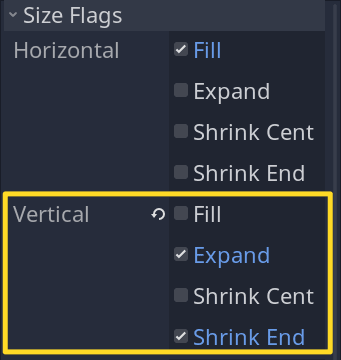

The *Size Flags* settings will get us a result like this, adding padding at the top without filling the entire parent

[figure not shown]

`Control` space.

### The systems node

Add the following new nodes to the *TacticalSpaceCombat* scene:

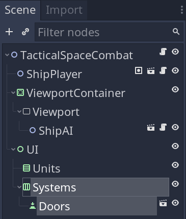

Systems is an

[figure not shown]

`HBoxContainer`, and *Doors* is our *UISystem* node created above. The *Doors* system will always be present in our demo, so we instantiate the node in the *TacticalSpaceCombat* scene tree right here.

Set the following properties on *Systems*:

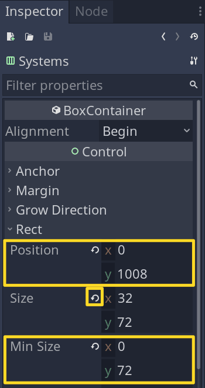

We set the *Position* to `Vector2(0, 1008)` and *Min Size* to `Vector2(0, 72)`, taking into account the game resolution of `1080` pixels vertically. We construct the weapons system with a vertical size of `72` pixels, so everything fits nicely with the *Systems* node aligned at the screen’s bottom-left.

### The weapons system

Create a new scene with the following tree:

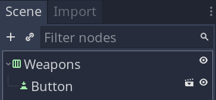

We’ll be adding weapon buttons, for player targeting, from code. That’s why the root node is an

[figure not shown]

`HBoxContainer`.

[figure not shown]

`Button` is the *UISystem* scene we built above. It has all the necessary properties already set for us. I just renamed it back to

[figure not shown]

`Button` because it’s uniquely identified under the *Weapons* parent node and chose to stick with the default node name.

Set *Rect -> Min Size* to `Vector2(0, 72)` on the *Weapons* node. We give it a fixed size, so we don’t have to worry about vertical alignment. Remember to reset *Size* if needed.

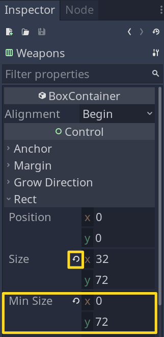

For

[figure not shown]

`Button`, set *Text* to `W` and turn on *Disabled*. We only use it in the game as a visual cue.

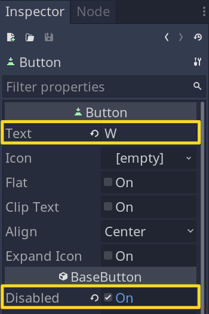

Save the scene file as `res://TacticalSpaceCombat/UI/UIWeapons.tscn`.

### The weapon targeting UI

Lets make the scene for weapon-player targeting. This will include a

[figure not shown]

`ProgressBar` that lets the player know how much time it takes for the weapon to charge.

Create a new scene with the following tree:

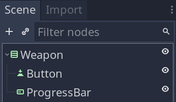

We have *Weapon* as root, which is a

[figure not shown]

`VBoxContainer`. Its children are a

[figure not shown]

`Button` and a

[figure not shown]

`ProgressBar`. This means they’ll be stacked vertically.

Set *Rect -> Min Size* to `Vector2(128, 72)` on *Weapon*. This will be the default size of the weapon targeting UI system.

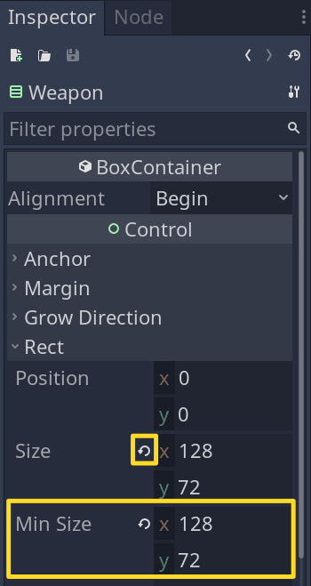

Let’s adjust the other nodes. Set *Text* to `Weapon` on

[figure not shown]

`Button` as a placeholder:

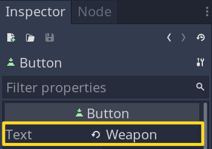

Make the button a toggle button by setting *Toggle Mode* to on. We want the player to enter a targeting mode when pressing this button.

Also, assign a new

[figure not shown]

`ButtonGroup` resource to *Group* and make sure *Local To Scene* is off. This will enable the buttons to function as radio buttons. We don’t want the player to enter multiple targeting modes at the same time.

We need to disable the *Local To Scene* property. Otherwise, Godot will create a new

[figure not shown]

`ButtonGroup` resource with each

[figure not shown]

`Button`, and they won’t behave as expected.

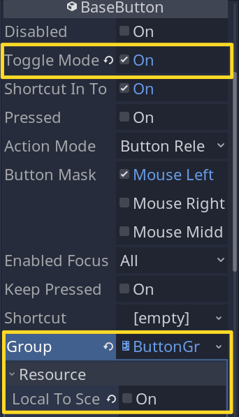

For our last *Inspector* property, we enable both *Fill* and *Expand* on the *Size Flags -> Vertical* field.

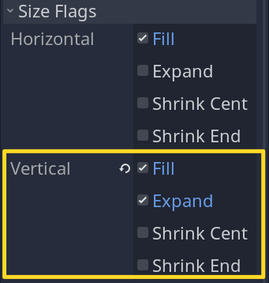

This will make the button take as much space as possible vertically.

For the

[figure not shown]

`ProgressBar`, uncheck *Percent -> Visible*. We want to keep only the bar itself, without any text, so it takes as little space as possible.

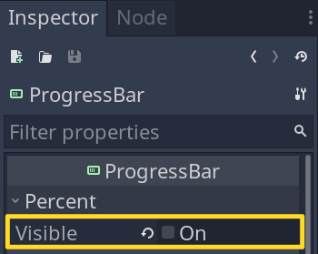

Set *Rect -> Min Size* to `Vector2(0, 8)` and rset the *Size* if needed.

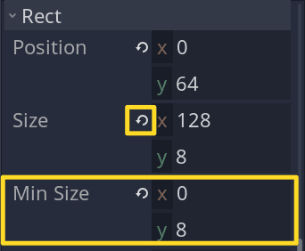

You should get this result:

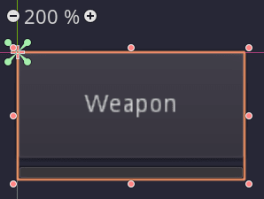

Save the scene as `res://TacticalSpaceCombat/UI/UIWeapon.tscn`.

## Coding the Doors system

As a final touch, we’ll add a way for the player to open and close doors when pressing the *Doors* system button.

This will have gameplay consequences when we code oxygen loss on hull breaches.

Open the `ShipTemplate.gd` script and add the following function:

```
## Open doors if none are already open, otherwise close them.
func _on_UIDoorsButton_pressed() -> void:
    var has_opened_doors := false
    for door in doors.get_children():
        if door.is_open:
            has_opened_doors = true
            break

    for door in doors.get_children():
        door.is_open = not has_opened_doors
```

We finish by adding the signal connections to make the *Doors* button work. Open the `TacticalSpaceCombat.gd` script and start by adding the `ui_doors` variable:

```
# ...
# onready var ui_units: VBoxContainer = $UI/Units
onready var ui_doors: Button = $UI/Systems/Doors
```

Now let’s connect the `pressed` signal in the `_ready()` function:

```
# ...
func _ready() -> void:
    ui_doors.connect("pressed", ship_player, "_on_UIDoorsButton_pressed")
    # ...
```

## Conclusion

In this lesson, we built the necessary scenes to implement the player ship systems UI.

We saw how to use

[figure not shown]

`HBoxContainer` and

[figure not shown]

`VBoxContainer` for automatic alignment in a complex system’s layout.

As a final touch, we implemented the player-doors interaction. This will become relevant for gameplay after we implement oxygen loss on hull breaches.

We’ll cover how to dynamically add the UI weapons system if the player ship has weapons attached in the following lessons.

## Code reference

`res://TacticalSpaceCombat/Ship/ShipTemplate.gd`:

```
tool
extends Node2D

const LaserTracker := preload("Weapons/LaserTracker.tscn")

var _slots := {}

onready var tilemap: TileMap = $TileMap
onready var rooms: Node2D = $Rooms
onready var doors: Node2D = $Doors
onready var units: Node2D = $Units
onready var weapons: Node2D = $Weapons
onready var projectiles: Node2D = $Projectiles
onready var lasers: Node2D = $Lasers


func _ready() -> void:
    call("_ready_editor_hint" if Engine.editor_hint else "_ready_not_editor_hint")


func _ready_editor_hint() -> void:
    for room in rooms.get_children():
        room.setup(tilemap)


func _ready_not_editor_hint() -> void:
    for unit in units.get_children():
        for door in doors.get_children():
            door.connect("opened", unit, "set_is_walking", [true])

        var position_map := tilemap.world_to_map(unit.path_follow.position)
        _slots[position_map] = unit

    for room in rooms.get_children():
        room.setup(tilemap)
        for point in room:
            tilemap.set_cellv(point, 0)
    tilemap.setup(rooms, doors)
    projectiles.setup(rooms.mean_position)


func _unhandled_input(event: InputEvent) -> void:
    if not event.is_action_pressed("right_click"):
        return

    for unit in get_tree().get_nodes_in_group("selected-unit"):
        var point1: Vector2 = tilemap.world_to_map(unit.path_follow.position)
        for room in get_tree().get_nodes_in_group("selected-room"):
            if not room.owner.is_in_group("player"):
                break

            var point2: Vector2 = room.get_slot(_slots, unit)
            if is_inf(point2.x):
                break

            var path: Curve2D = tilemap.find_path(point1, point2)
            Utils.erase_value(_slots, unit)
            _slots[point2] = unit
            unit.walk(path)


func _on_UIDoorsButton_pressed() -> void:
    var has_opened_doors := false
    for door in doors.get_children():
        if door.is_open:
            has_opened_doors = true
            break

    for door in doors.get_children():
        door.is_open = not has_opened_doors


func add_laser_tracker(color: Color) -> Node:
    var laser_tracker := LaserTracker.instance()
    lasers.add_child(laser_tracker)
    laser_tracker.setup(color, rooms)
    return laser_tracker
```

`res://TacticalSpaceCombat.gd`:

```
extends Node2D

const UIUnit = preload("TacticalSpaceCombat/UI/UIUnit.tscn")

onready var ship_player: Node2D = $ShipPlayer
onready var ship_ai: Node2D = $ViewportContainer/Viewport/ShipAI
onready var ui_units: VBoxContainer = $UI/Units
onready var ui_doors: Button = $UI/Systems/Doors


func _ready() -> void:
    ui_doors.connect("pressed", ship_player, "_on_UIDoorsButton_pressed")

    _ready_units()
    _ready_weapons_ai()


func _ready_units() -> void:
    for unit in ship_player.units.get_children():
        var ui_unit: ColorRect = UIUnit.instance()
        ui_units.add_child(ui_unit)
        unit.setup(ui_unit)


func _ready_weapons_ai() -> void:
    for controller in ship_ai.weapons.get_children():
        if controller is ControllerAIProjectile:
            controller.connect("targeting", ship_player.rooms, "_on_Controller_targeting")
            controller.weapon.connect(
                "projectile_exited", ship_player.projectiles, "_on_Weapon_projectile_exited"
            )
            ship_player.rooms.connect("targeted", controller, "_on_Ship_targeted")
        elif controller is ControllerAILaser:
            var laser_tracker: Node = ship_player.add_laser_tracker(controller.weapon.color)
            controller.connect(
                "targeting", laser_tracker, "_on_Controller_targeting", [], CONNECT_DEFERRED
            )
            controller.weapon.connect("fire_started", laser_tracker, "_on_Weapon_fire_started")
            controller.weapon.connect("fire_stopped", laser_tracker, "_on_Weapon_fire_stopped")
            laser_tracker.connect("targeted", controller, "_on_Ship_targeted")
```